To plan the sample size of the study, we set our null model for the test-retest reliablity (using Pearson’s r) at 0.80, using a normal sampling distribution after transformation to Fisher’s z. Then, using a one-sided test of H0: r >= 0.8 vs H1: r < 0.8 with a type 1 error of 5%, we evaluated what our power would be to correctly reject the null under alternative true values for r.

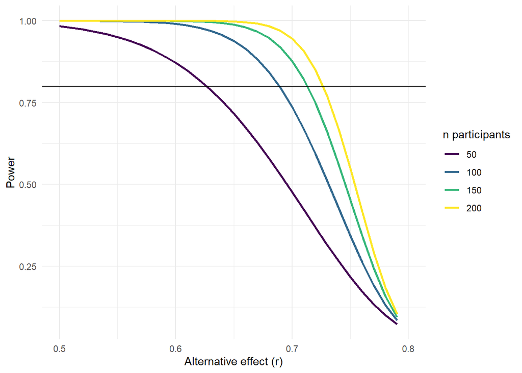

The plot above gives power for possible alternative values of r (x axis; between 0.5 to 0.79) as a function of sample size. If you following the yellow line, you can see that 200 participants (that is 200 pairs of tests) would give you 80% to correctly reject the null of 0.8 if the true values for r was 0.72 (with higher power for lower true values of r). At 50 participants, you would corectly reject the null of 0.8 is the true values for r was 0.63 80% of the time. Alternatively, you can think of this as saying, “If the truth was actually 0.63, I would still accept that r was = 0.8 20% of the time, based on a one-sided test with 5% type 1 error.” The question is whether you find this acceptable.

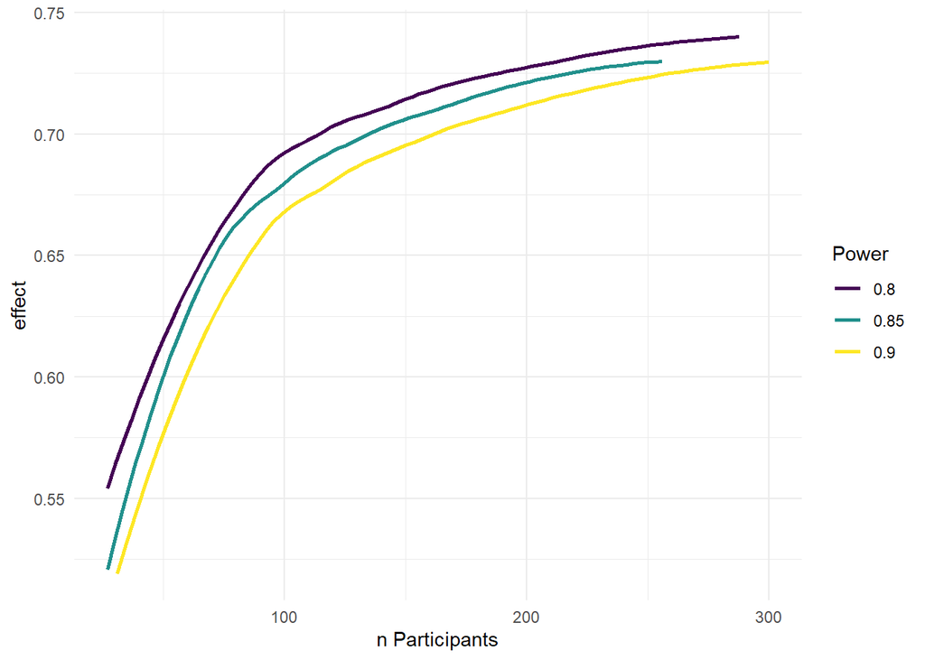

This is the same information, just reorganized. What sample would you need to correctly reject the null of r = 0.8 at a given alternative value for r, and a given power.